# Dictionary INS_Inschrijvingen_synthetic

## INS_Vooropleiding_voor_HO_profiel

| Feature | Result |
| --- | --- |
| Variable type | character |
| Number of missing obs. | 0 (0 %) |
| Number of unique values | 25 |
| Mode | “overig buitenlands diploma / Europees baccalaureaat” |

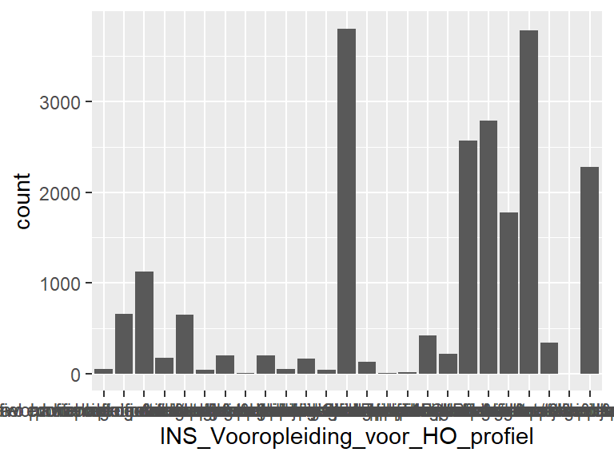

- Observed factor levels: "havo algemeen", "havo profiel cultuur & maatschappij", "havo profiel economie & maatschappij", "havo profiel economie/maatschappij & cultuur/maatschappij", "havo profiel natuur & gezondheid", …, "vwo profiel economie/maatschappij & cultuur/maatschappij", "vwo profiel natuur & gezondheid", "vwo profiel natuur & techniek", "vwo profiel natuur/gezondheid & cultuur/maatschappij", "vwo profiel natuur/techniek & natuur/gezondheid" (15 values omitted).

## INS_Vooropleiding_voor_HO_omschrijving

| Feature | Result |
| --- | --- |
| Variable type | character |
| Number of missing obs. | 0 (0 %) |
| Number of unique values | 6 |
| Mode | “vwo” |

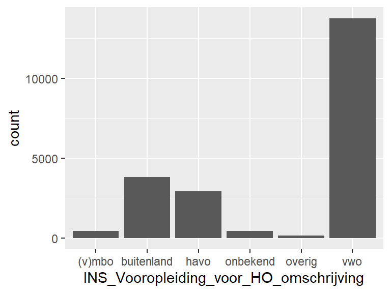

- Observed factor levels: "(v)mbo", "buitenland", "havo", "onbekend", "overig", "vwo".

## INS_Vooropleiding_binnen_HO_soort

| Feature | Result |
| --- | --- |
| Variable type | character |
| Number of missing obs. | 0 (0 %) |
| Number of unique values | 5 |
| Mode | “onbekend” |

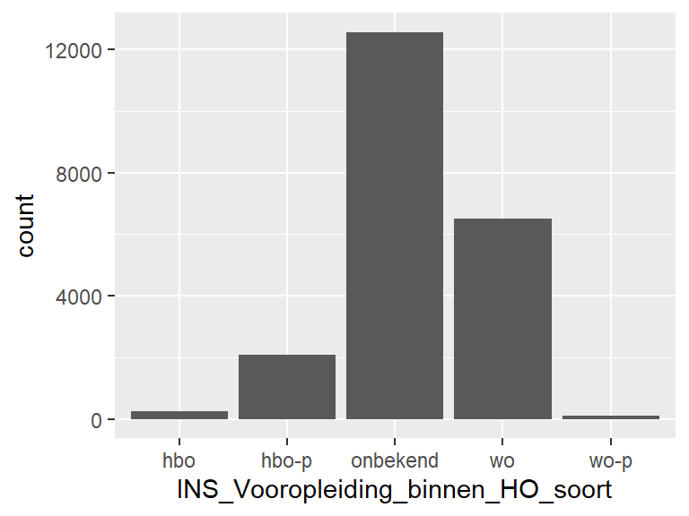

- Observed factor levels: "hbo", "hbo-p", "onbekend", "wo", "wo-p".

## INS_Hoogste_vooropleiding_nieuw_cat

| Feature | Result |
| --- | --- |
| Variable type | character |
| Number of missing obs. | 0 (0 %) |
| Number of unique values | 10 |
| Mode | “vwo” |

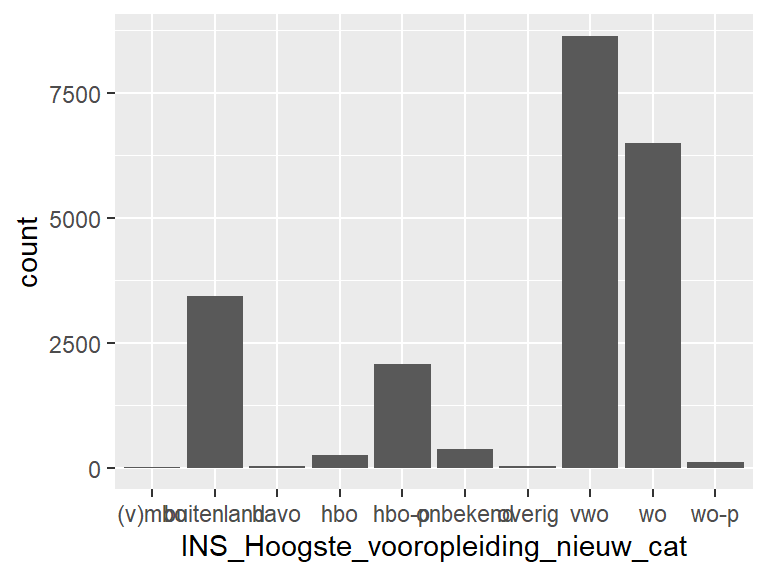

- Observed factor levels: "(v)mbo", "buitenland", "havo", "hbo", "hbo-p", "onbekend", "overig", "vwo", "wo", "wo-p".

## INS_Vooropleiding_voor_HO_naam

| Feature | Result |
| --- | --- |
| Variable type | character |
| Number of missing obs. | 4696 (21.83 %) |
| Number of unique values | 495 |
| Mode | “ROC van Amsterdam” |

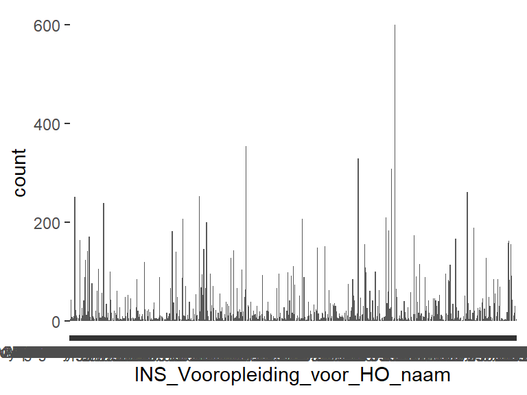

- Observed factor levels: "2College", "Adelbert College", "Agnieten College", "Albeda", "Alfa-college", …, "Zadkine", "Zeldenrust Steelantcollege", "Zernike College", "Zuyderzee Lyceum", "Zwin College SGM" (485 values omitted).

## INS_Vooropleiding_binnen_HO_naam

| Feature | Result |
| --- | --- |
| Variable type | character |
| Number of missing obs. | 12684 (58.98 %) |
| Number of unique values | 51 |
| Mode | “Vrije Universiteit Amsterdam” |

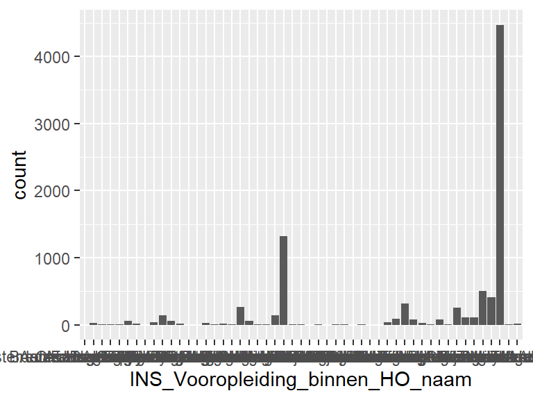

- Observed factor levels: "Aeres Hogeschool", "Amsterdamse Hogesch vd Kunsten", "ArtEZ", "Avans Hogeschool", "Breda Univ of Applied Sciences", …, "Universiteit Utrecht", "Universiteit van Amsterdam", "Vrije Universiteit Amsterdam", "WU", "Zuyd Hogeschool" (41 values omitted).

## INS_Hoogste_vooropleiding_instellingsnaam

| Feature | Result |
| --- | --- |
| Variable type | character |
| Number of missing obs. | 4127 (19.19 %) |
| Number of unique values | 440 |
| Mode | “Vrije Universiteit Amsterdam” |

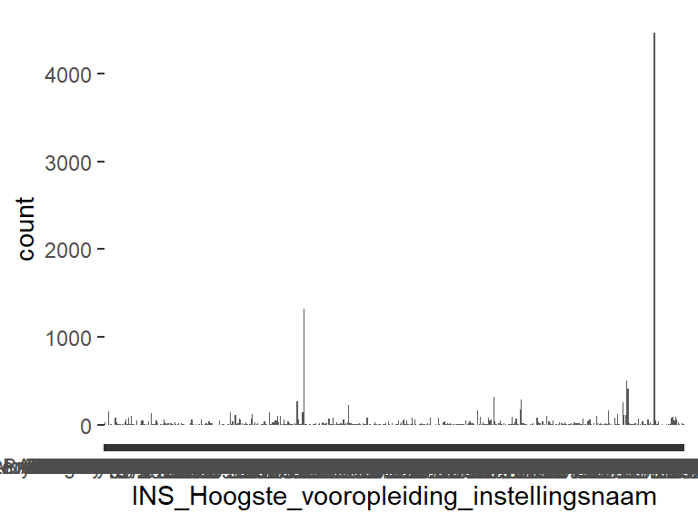

- Observed factor levels: "Adelbert College", "Aeres Hogeschool", "Alfa-college", "Alkwin Kollege", "Almende College", …, "Zadkine", "Zeldenrust Steelantcollege", "Zernike College", "Zuyd Hogeschool", "Zuyderzee Lyceum" (430 values omitted).

## INS_Vooropleiding_voor_HO_postcode

| Feature | Result |
| --- | --- |
| Variable type | numeric |
| Number of missing obs. | 4696 (21.83 %) |
| Number of unique values | 408 |
| Median | 1817 |
| 1st and 3rd quartiles | 1213; 3621 |
| Min. and max. | 1013; 9989 |

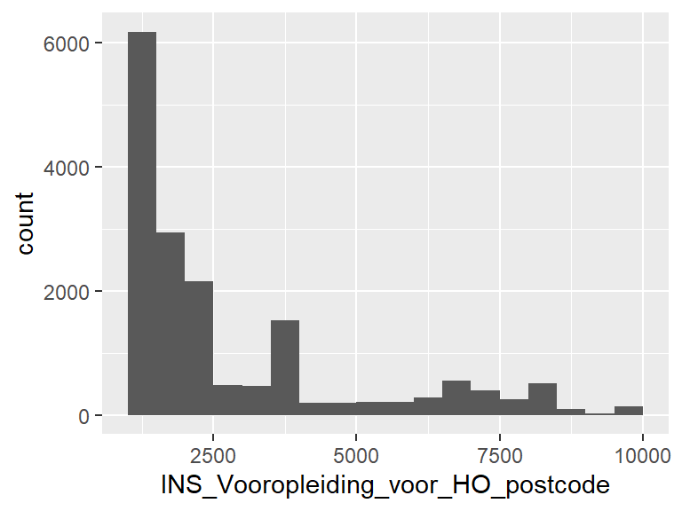

## INS_Vooropleiding_binnen_HO_postcode

| Feature | Result |
| --- | --- |
| Variable type | numeric |
| Number of missing obs. | 12684 (58.98 %) |
| Number of unique values | 44 |
| Median | 1081 |
| 1st and 3rd quartiles | 1081; 2595 |
| Min. and max. | 1011; 9747 |

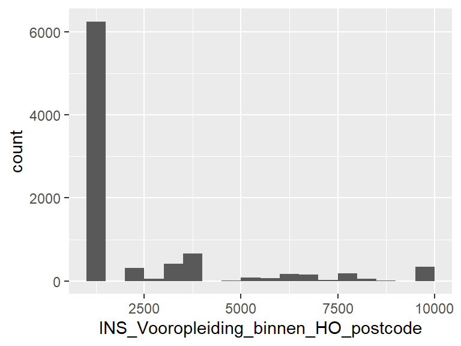

## INS_Hoogste_vooropleiding_postcode

| Feature | Result |
| --- | --- |
| Variable type | numeric |
| Number of missing obs. | 4127 (19.19 %) |
| Number of unique values | 353 |
| Median | 1217 |
| 1st and 3rd quartiles | 1081; 2625 |
| Min. and max. | 1011; 9901 |

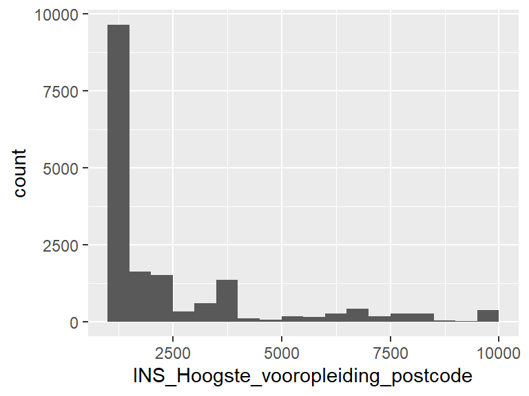

## INS_Vooropleiding_voor_HO_plaats

| Feature | Result |
| --- | --- |
| Variable type | character |
| Number of missing obs. | 4696 (21.83 %) |
| Number of unique values | 204 |
| Mode | “AMSTERDAM” |

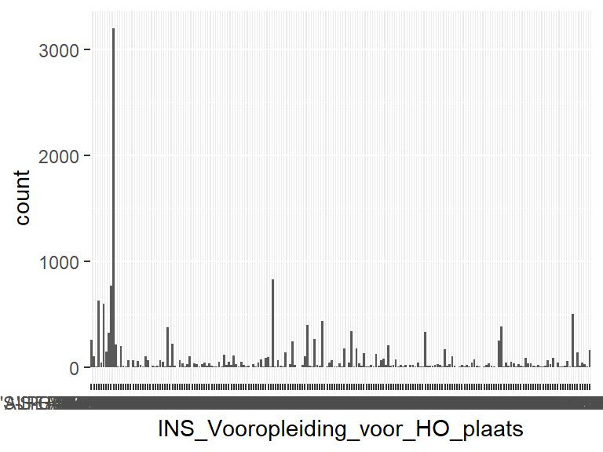

- Observed factor levels: "’S-GRAVENHAGE", "’S-HERTOGENBOSCH", "AALTEN", "ALKMAAR", "ALMELO", …, "ZEVENAAR", "ZOETERMEER", "ZUTPHEN", "ZWIJNDRECHT", "ZWOLLE" (194 values omitted).

## INS_Vooropleiding_binnen_HO_plaats

| Feature | Result |
| --- | --- |
| Variable type | character |
| Number of missing obs. | 12684 (58.98 %) |
| Number of unique values | 25 |
| Mode | “AMSTERDAM” |

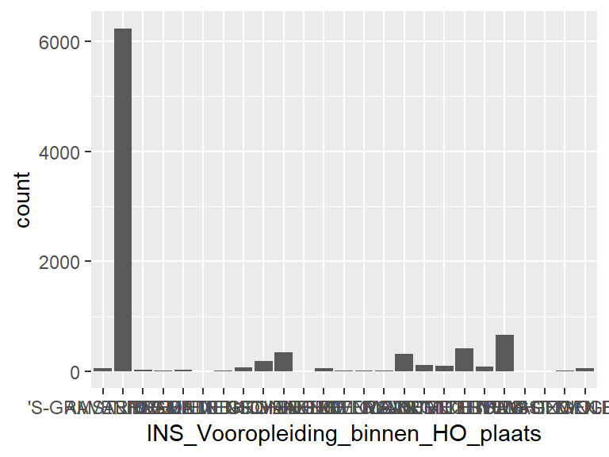

- Observed factor levels: "’S-GRAVENHAGE", "AMSTERDAM", "ARNHEM", "BREDA", "DEVENTER", …, "UTRECHT", "VELP GLD", "VLISSINGEN", "WAGENINGEN", "ZWOLLE" (15 values omitted).

## INS_Hoogste_vooropleiding_plaats

| Feature | Result |
| --- | --- |
| Variable type | character |
| Number of missing obs. | 4127 (19.19 %) |
| Number of unique values | 168 |
| Mode | “AMSTERDAM” |

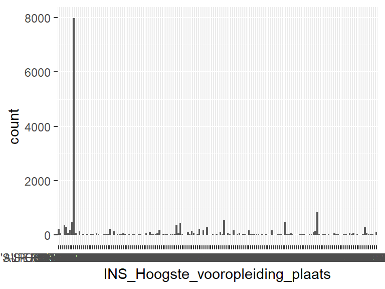

- Observed factor levels: "’S-GRAVENHAGE", "’S-HERTOGENBOSCH", "AALTEN", "ALKMAAR", "ALMERE", …, "ZEVENAAR", "ZOETERMEER", "ZUTPHEN", "ZWIJNDRECHT", "ZWOLLE" (158 values omitted).

## INS_Examenresultaat_omschrijving

| Feature | Result |
| --- | --- |
| Variable type | character |
| Number of missing obs. | 16446 (76.47 %) |
| Number of unique values | 2 |
| Mode | “Examen behaald” |

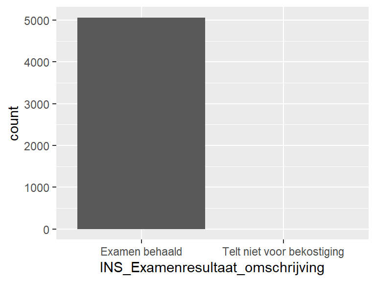

- Observed factor levels: "Examen behaald", "Telt niet voor bekostiging".

## INS_Indicatie_eerste_jaars_instelling_cat

| Feature | Result |
| --- | --- |
| Variable type | character |
| Number of missing obs. | 0 (0 %) |
| Number of unique values | 3 |
| Mode | “Ouderejaars VU” |

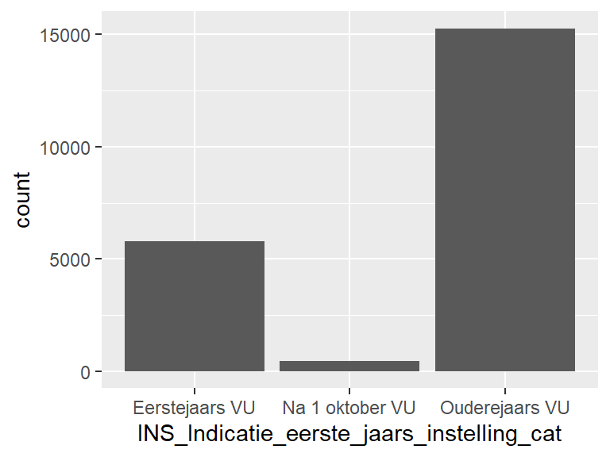

- Observed factor levels: "Eerstejaars VU", "Na 1 oktober VU", "Ouderejaars VU".

## INS_Indicatie_eerste_jaars_instelling_naam

| Feature | Result |
| --- | --- |
| Variable type | character |
| Number of missing obs. | 0 (0 %) |
| Number of unique values | 5 |
| Mode | “Hoofd - Ouderejaars VU” |

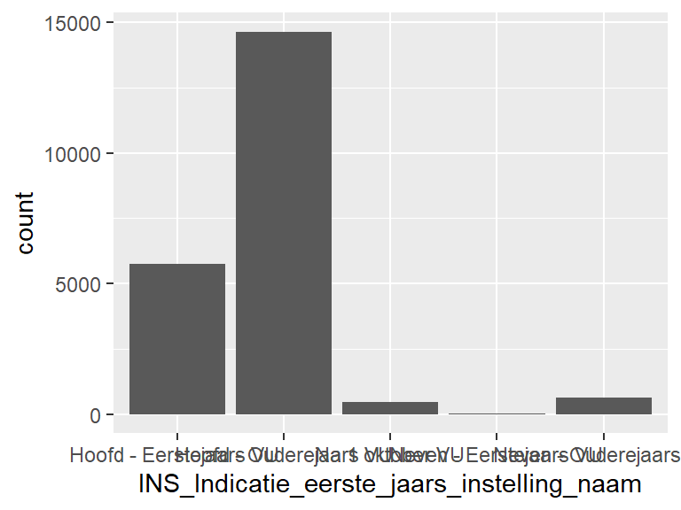

- Observed factor levels: "Hoofd - Eerstejaars VU ", "Hoofd - Ouderejaars VU", "Na 1 oktober VU", "Neven - Eerstejaars VU", "Neven - Ouderejaars VU".

## INS_Indicatie_eerste_jaars_opleiding_en_instelling_naam

| Feature | Result |
| --- | --- |
| Variable type | character |
| Number of missing obs. | 0 (0 %) |
| Number of unique values | 3 |
| Mode | “Ouderejaars opleiding” |

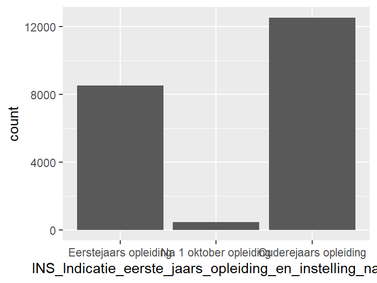

- Observed factor levels: "Eerstejaars opleiding", "Na 1 oktober opleiding", "Ouderejaars opleiding".

## DEM_Nationaliteit_1_naam

| Feature | Result |
| --- | --- |
| Variable type | character |
| Number of missing obs. | 0 (0 %) |
| Number of unique values | 90 |
| Mode | “Nederlandse” |

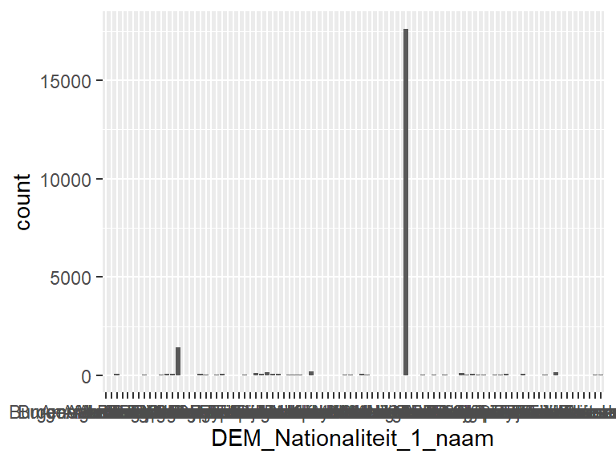

- Observed factor levels: "Afghaanse", "Albanese", "Amerikaans burger", "Armeense", "Australische", …, "Zuid-Afrikaanse", "Zuid-Koreaanse", "Zuid-Soedanese", "Zweedse", "Zwitserse" (80 values omitted).

## DEM_Nationaliteit_2_naam

| Feature | Result |
| --- | --- |
| Variable type | character |
| Number of missing obs. | 0 (0 %) |
| Number of unique values | 97 |
| Mode | “NULL” |

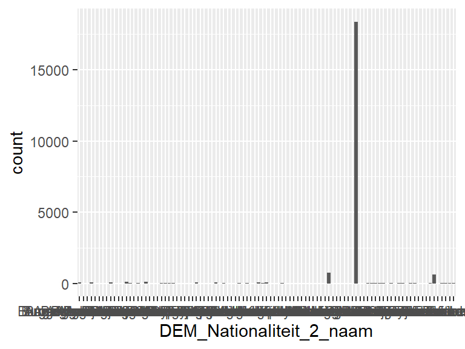

- Observed factor levels: "Afghaanse", "Albanese", "Algerijnse", "Amerikaans burger", "Amerikaans onderdaan", …, "Venezolaanse", "Vietnamese", "Zuid-Afrikaanse", "Zweedse", "Zwitserse" (87 values omitted).

## DEM_Nationaliteit_3_naam

| Feature | Result |
| --- | --- |
| Variable type | character |
| Number of missing obs. | 0 (0 %) |
| Number of unique values | 13 |
| Mode | “NULL” |

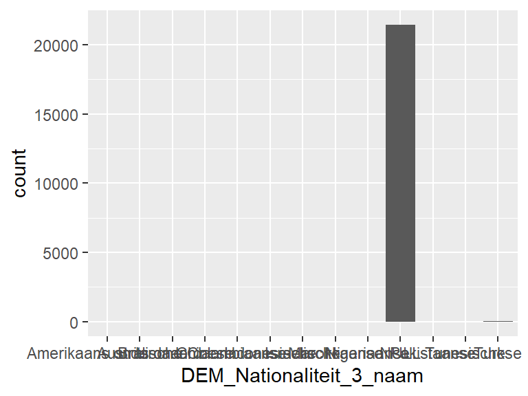

- Observed factor levels: "Amerikaans onderdaan", "Australische", "Brits onderdaan", "Chinese", "Colombiaanse", …, "Nigeriaanse", "NULL", "Pakistaanse", "Tunesische", "Turkse" (3 values omitted).

## DEM_Leeftijd_peildatum_1_jan_cat

| Feature | Result |
| --- | --- |
| Variable type | factor |
| Number of missing obs. | 0 (0 %) |
| Number of unique values | 7 |
| Mode | “21-22” |
| Reference category | Onder 18 |

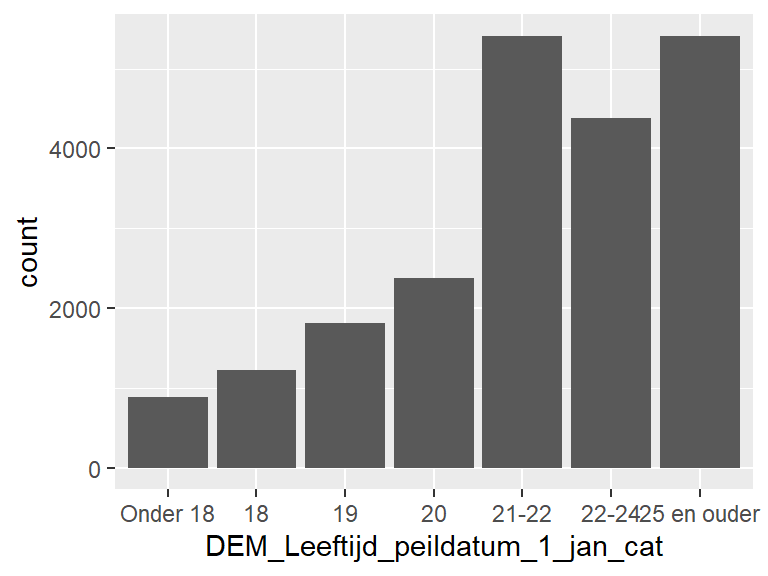

- Observed factor levels: "18", "19", "20", "21-22", "22-24", "25 en ouder", "Onder 18".

## INS_Soort_inschrijving_1CHO_cat

| Feature | Result |
| --- | --- |
| Variable type | character |
| Number of missing obs. | 0 (0 %) |
| Number of unique values | 3 |
| Mode | “Hoofdinschrijving” |

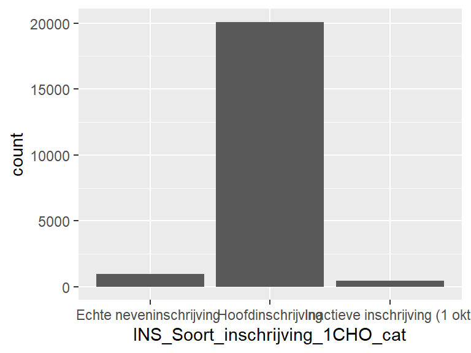

- Observed factor levels: "Echte neveninschrijving ", "Hoofdinschrijving", "Inactieve inschrijving (1 okt)".

## INS_Vooropleiding_binnen_HO_Instellingsnaam

| Feature | Result |
| --- | --- |
| Variable type | character |
| Number of missing obs. | 12684 (58.98 %) |
| Number of unique values | 51 |
| Mode | “Vrije Universiteit Amsterdam” |

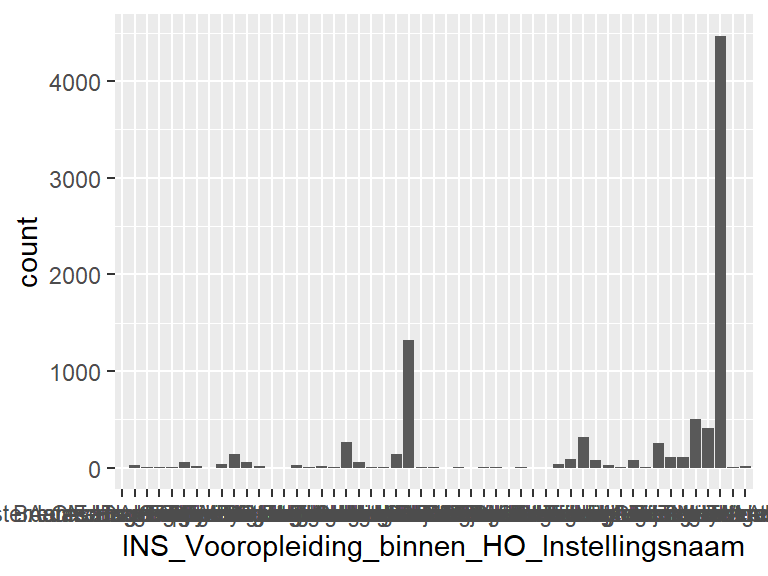

- Observed factor levels: "Aeres Hogeschool", "Amsterdamse Hogesch vd Kunsten", "ArtEZ", "Avans Hogeschool", "Breda Univ of Applied Sciences", …, "Universiteit Utrecht", "Universiteit van Amsterdam", "Vrije Universiteit Amsterdam", "WU", "Zuyd Hogeschool" (41 values omitted).

## INS_Vooropleiding_voor_HO_Instellingsnaam

| Feature | Result |
| --- | --- |
| Variable type | character |
| Number of missing obs. | 4696 (21.83 %) |
| Number of unique values | 495 |
| Mode | “ROC van Amsterdam” |

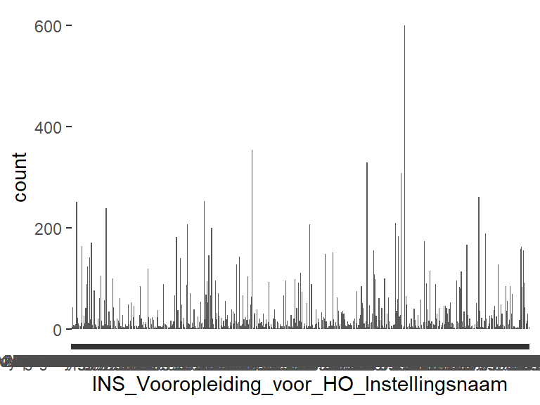

- Observed factor levels: "2College", "Adelbert College", "Agnieten College", "Albeda", "Alfa-college", …, "Zadkine", "Zeldenrust Steelantcollege", "Zernike College", "Zuyderzee Lyceum", "Zwin College SGM" (485 values omitted).

## INS_Indicatie_actief_op_peildatum_omschrijving

| Feature | Result |
| --- | --- |
| Variable type | character |
| Number of missing obs. | 0 (0 %) |
| Number of unique values | 3 |
| Mode | “actief” |

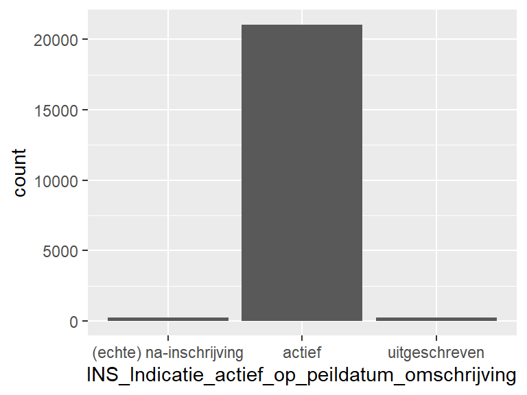

- Observed factor levels: "(echte) na-inschrijving", "actief", "uitgeschreven".

## INS_Opleidingsfase_actueel_naam

| Feature | Result |
| --- | --- |
| Variable type | character |
| Number of missing obs. | 0 (0 %) |
| Number of unique values | 2 |
| Mode | “Bachelor” |

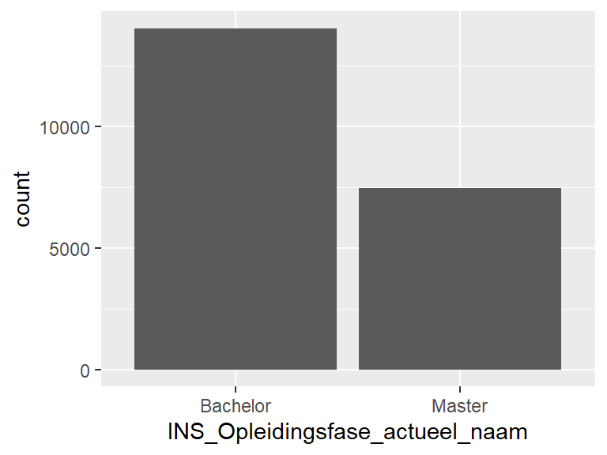

- Observed factor levels: "Bachelor", "Master".

## INS_Opleidingsvorm_code

- The variable only takes one (non-missing) value: "1". The variable contains 0 % missing observations.

## DEM_Leeftijd_peildatum_1_oktober_cat

| Feature | Result |
| --- | --- |
| Variable type | factor |
| Number of missing obs. | 0 (0 %) |
| Number of unique values | 7 |
| Mode | “21-22” |
| Reference category | Onder 18 |

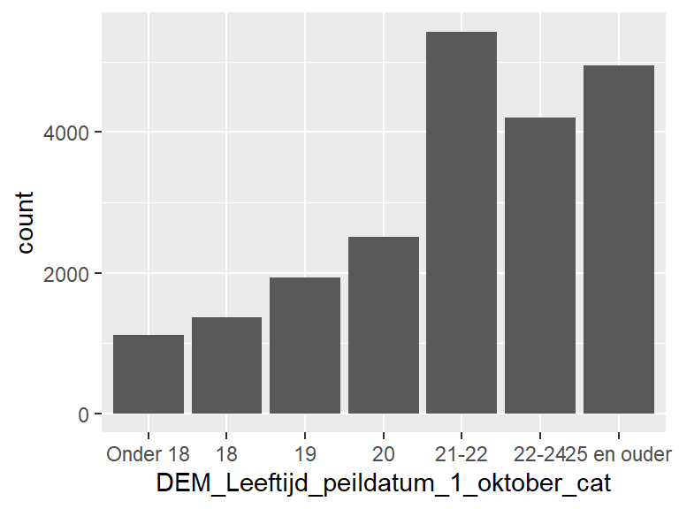

- Observed factor levels: "18", "19", "20", "21-22", "22-24", "25 en ouder", "Onder 18".

## DEM_Geslacht_naam

| Feature | Result |
| --- | --- |
| Variable type | character |
| Number of missing obs. | 0 (0 %) |
| Number of unique values | 3 |
| Mode | “Vrouw” |

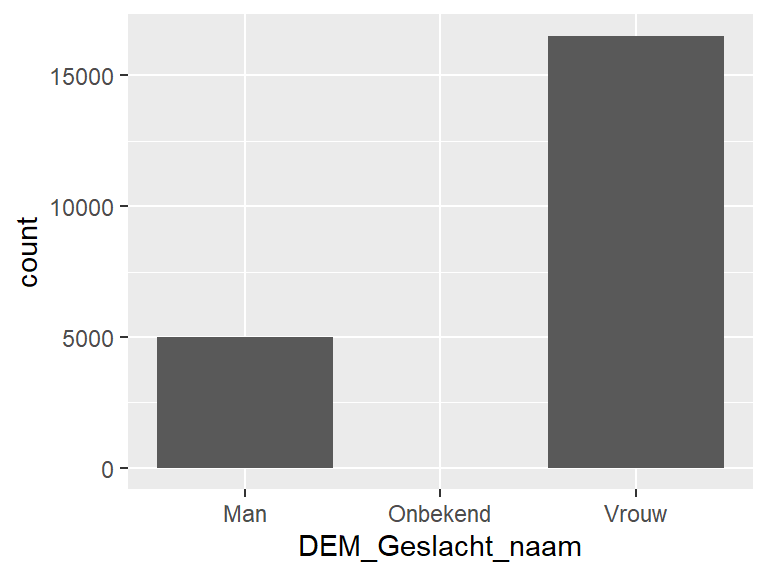

- Observed factor levels: "Man", "Onbekend", "Vrouw".

## INS_Verblijfsjaren_wetenschappelijk_onderwijs_vanaf_0_cat

| Feature | Result |
| --- | --- |
| Variable type | factor |
| Number of missing obs. | 458 (2.13 %) |
| Number of unique values | 7 |
| Mode | “0” |
| Reference category | 0 |

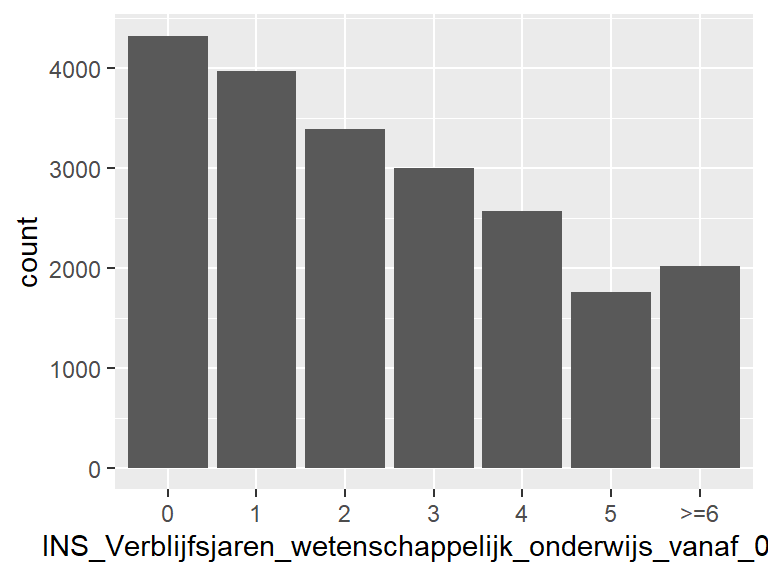

- Observed factor levels: ">=6", "0", "1", "2", "3", "4", "5".

## INS_Verblijfsjaren_hoger_onderwijs_vanaf_0_cat

| Feature | Result |
| --- | --- |
| Variable type | factor |
| Number of missing obs. | 458 (2.13 %) |
| Number of unique values | 7 |
| Mode | “1” |
| Reference category | 0 |

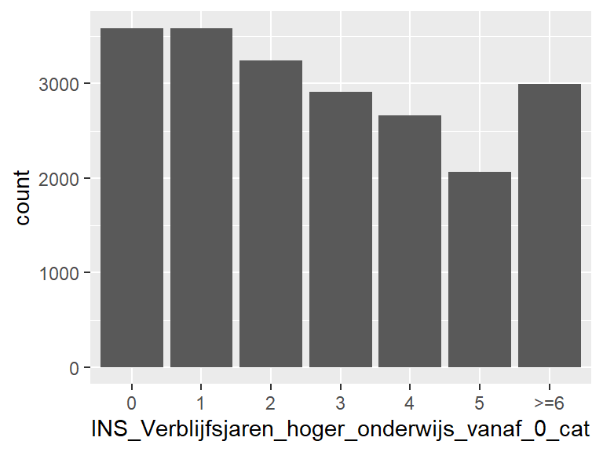

- Observed factor levels: ">=6", "0", "1", "2", "3", "4", "5".

## INS_Opleidingsfase_BPM

| Feature | Result |
| --- | --- |
| Variable type | character |
| Number of missing obs. | 0 (0 %) |
| Number of unique values | 2 |
| Mode | “B” |

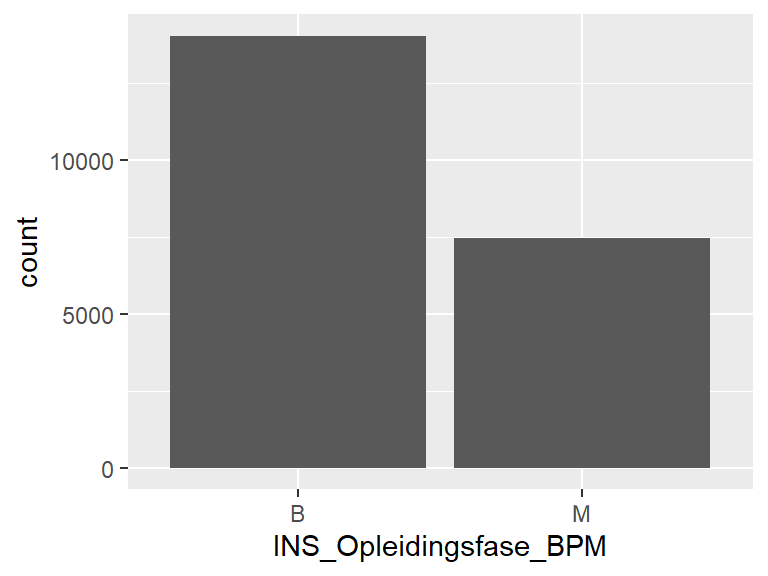

- Observed factor levels: "B", "M".

## INS_Uitwonend

| Feature | Result |
| --- | --- |
| Variable type | logical |
| Number of missing obs. | 4645 (21.6 %) |
| Number of unique values | 2 |
| Mode | “TRUE” |

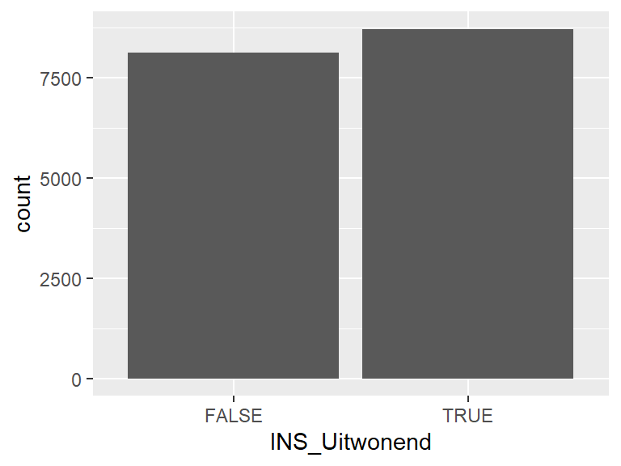

## INS_Indicatie_voltijd

- The variable only takes one (non-missing) value: "TRUE". The variable contains 0 % missing observations.

## INS_Aantal_inschrijvingen_jaar_instelling

- The variable only takes one (non-missing) value: "1". The variable contains 0 % missing observations.

## INS_Aantal_EOI_inschrijvingen_jaar_instelling

| Feature | Result |
| --- | --- |
| Variable type | integer |
| Number of missing obs. | 0 (0 %) |
| Number of unique values | 3 |
| Median | 0 |
| 1st and 3rd quartiles | 0; 1 |
| Min. and max. | 0; 2 |

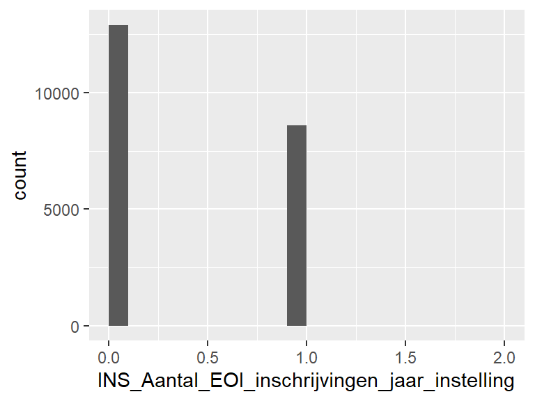

## INS_Dubbele_studie_instelling

- The variable only takes one (non-missing) value: "FALSE". The variable contains 0 % missing observations.

## INS_Vooropleiding_voor_HO_profiel_standaard

| Feature | Result |
| --- | --- |
| Variable type | character |
| Number of missing obs. | 5109 (23.76 %) |
| Number of unique values | 7 |
| Mode | “natuur & gezondheid” |

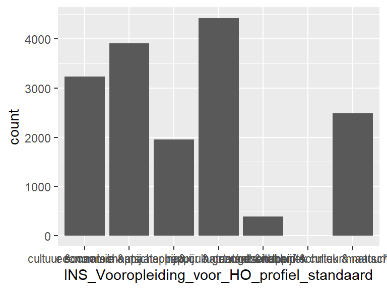

- Observed factor levels: "cultuur & maatschappij", "economie & maatschappij", "economie/maatschappij & cultuur/maatschappij", "natuur & gezondheid", "natuur & techniek", "natuur/gezondheid & cultuur/maatschappij", "natuur/techniek & natuur/gezondheid".

## INS_Vooropleiding_voor_HO_profiel_standaard_alleen_VWO

| Feature | Result |
| --- | --- |
| Variable type | character |
| Number of missing obs. | 7968 (37.05 %) |
| Number of unique values | 7 |
| Mode | “natuur & gezondheid” |

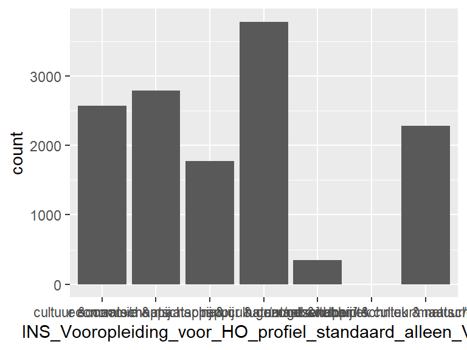

- Observed factor levels: "cultuur & maatschappij", "economie & maatschappij", "economie/maatschappij & cultuur/maatschappij", "natuur & gezondheid", "natuur & techniek", "natuur/gezondheid & cultuur/maatschappij", "natuur/techniek & natuur/gezondheid".

## INS_Vooropleiding_voor_HO_profiel_standaard_NT

| Feature | Result |
| --- | --- |
| Variable type | logical |
| Number of missing obs. | 0 (0 %) |
| Number of unique values | 2 |
| Mode | “FALSE” |

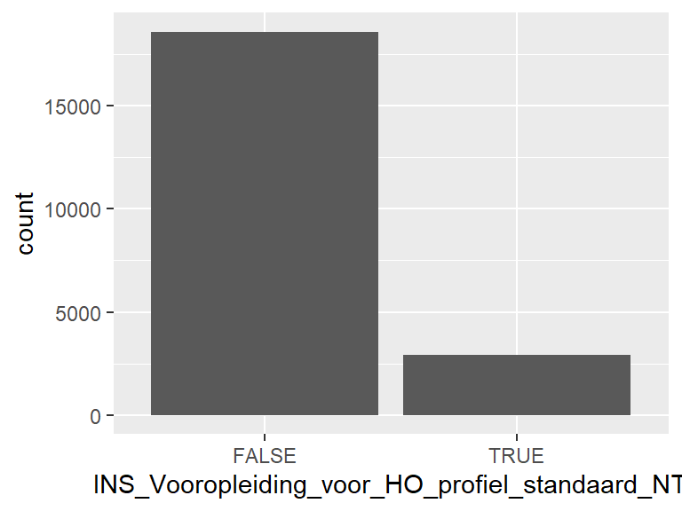

## INS_Vooropleiding_voor_HO_profiel_standaard_NG

| Feature | Result |
| --- | --- |
| Variable type | logical |
| Number of missing obs. | 0 (0 %) |
| Number of unique values | 2 |
| Mode | “FALSE” |

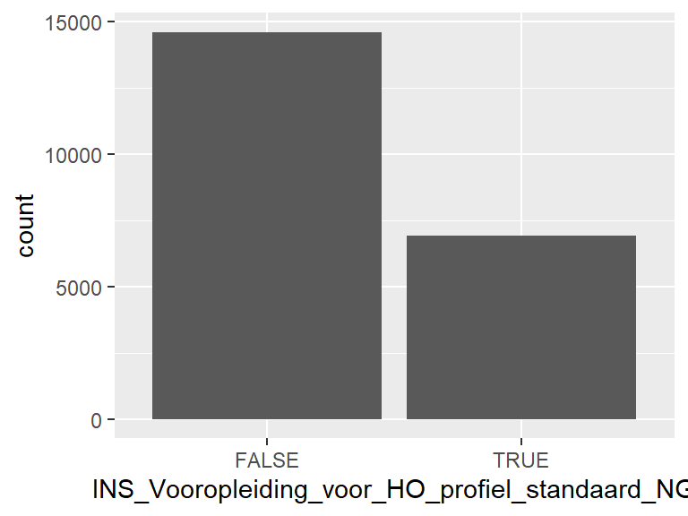

## INS_Vooropleiding_voor_HO_profiel_standaard_EM

| Feature | Result |
| --- | --- |
| Variable type | logical |
| Number of missing obs. | 0 (0 %) |
| Number of unique values | 2 |
| Mode | “FALSE” |

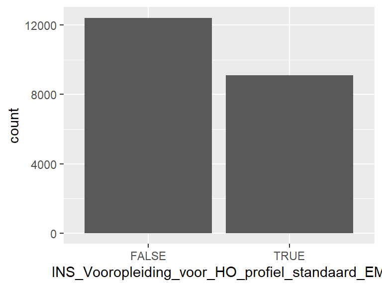

## INS_Vooropleiding_voor_HO_profiel_standaard_CM

| Feature | Result |
| --- | --- |
| Variable type | logical |
| Number of missing obs. | 0 (0 %) |
| Number of unique values | 2 |
| Mode | “FALSE” |

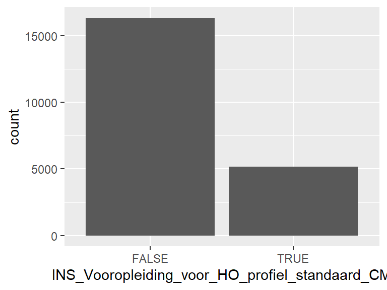

## INS_Vooropleiding_voor_HO_profiel_standaard_alleen_VWO_combinatieprofiel

| Feature | Result |
| --- | --- |
| Variable type | logical |
| Number of missing obs. | 7968 (37.05 %) |
| Number of unique values | 2 |
| Mode | “FALSE” |

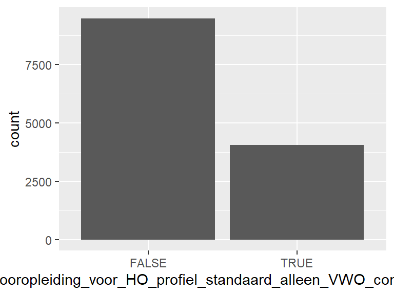

## INS_Vooropleiding_voor_HO_profiel_standaard_afk

| Feature | Result |
| --- | --- |
| Variable type | character |
| Number of missing obs. | 5109 (23.76 %) |
| Number of unique values | 7 |
| Mode | “NG” |

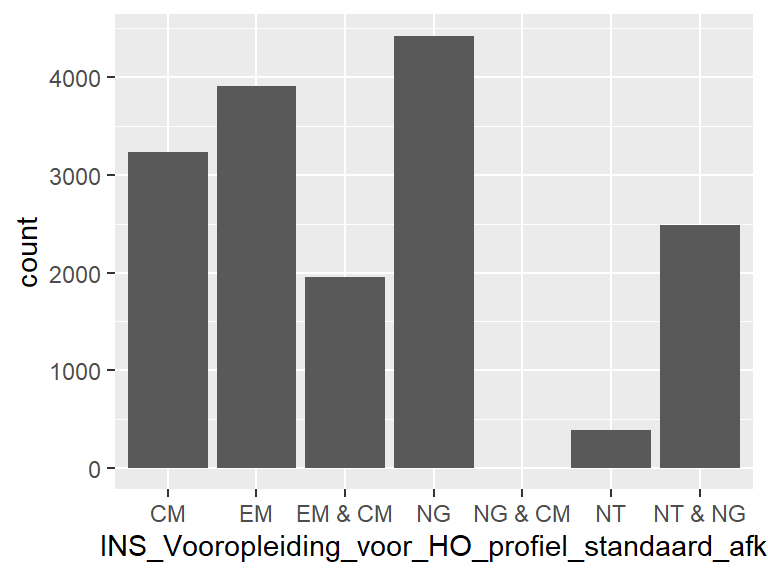

- Observed factor levels: "CM", "EM", "EM & CM", "NG", "NG & CM", "NT", "NT & NG".

## INS_Vooropleiding_voor_HO_profiel_standaard_alleen_VWO_afk

| Feature | Result |
| --- | --- |
| Variable type | character |
| Number of missing obs. | 7968 (37.05 %) |
| Number of unique values | 7 |
| Mode | “NG” |

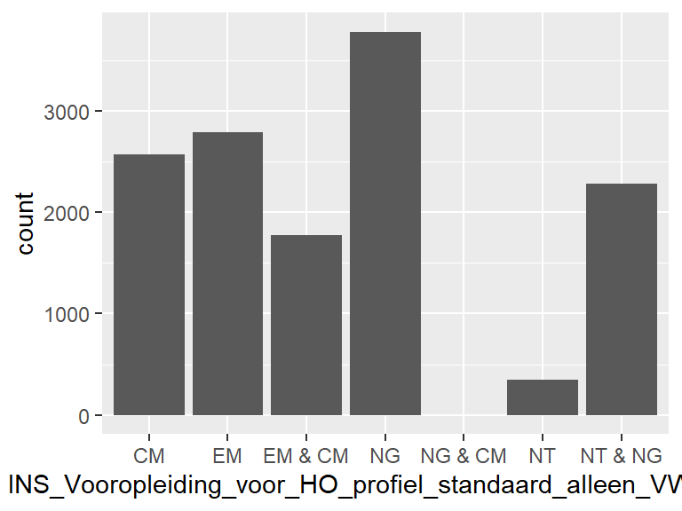

- Observed factor levels: "CM", "EM", "EM & CM", "NG", "NG & CM", "NT", "NT & NG".

## INS_Vooropleiding_voor_HO_profiel_standaard_zonder_combinatie

- The variable only takes one value: "NA".

## INS_Vooropleiding_voor_HO_profiel_standaard_alleen_VWO_zonder_combinatie

- The variable only takes one value: "NA".

## INS_Inschrijvingsjaar_EOI_SAP

| Feature | Result |
| --- | --- |
| Variable type | numeric |
| Number of missing obs. | 0 (0 %) |
| Number of unique values | 13 |
| Median | 2017 |
| 1st and 3rd quartiles | 2013; 2019 |
| Min. and max. | 2010; 2022 |

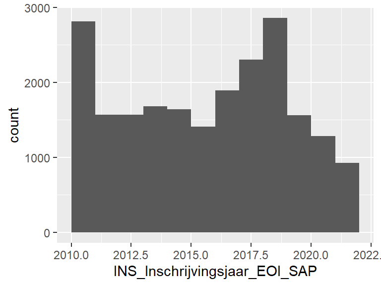

## INS_Studiejaar

| Feature | Result |
| --- | --- |
| Variable type | integer |
| Number of missing obs. | 0 (0 %) |
| Number of unique values | 12 |
| Median | 2 |
| 1st and 3rd quartiles | 1; 3 |
| Min. and max. | 1; 12 |

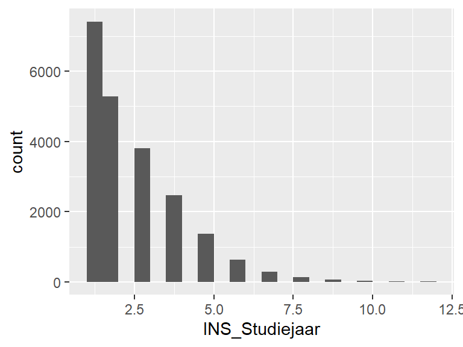

## INS_Tussenjaren_binnen_opleiding

| Feature | Result |
| --- | --- |
| Variable type | integer |
| Number of missing obs. | 0 (0 %) |
| Number of unique values | 7 |
| Median | 0 |
| 1st and 3rd quartiles | 0; 0 |
| Min. and max. | 0; 6 |

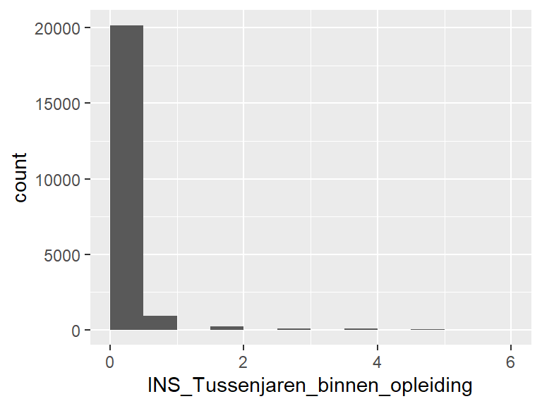

## INS_Inschrijvingsjaar_is_EOI

| Feature | Result |
| --- | --- |
| Variable type | logical |
| Number of missing obs. | 0 (0 %) |
| Number of unique values | 2 |
| Mode | “FALSE” |

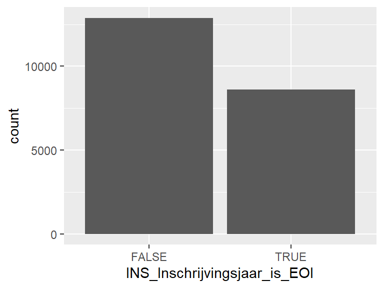

## INS_Uitschrijving_voor_1_feb

| Feature | Result |
| --- | --- |
| Variable type | logical |
| Number of missing obs. | 0 (0 %) |
| Number of unique values | 2 |
| Mode | “FALSE” |

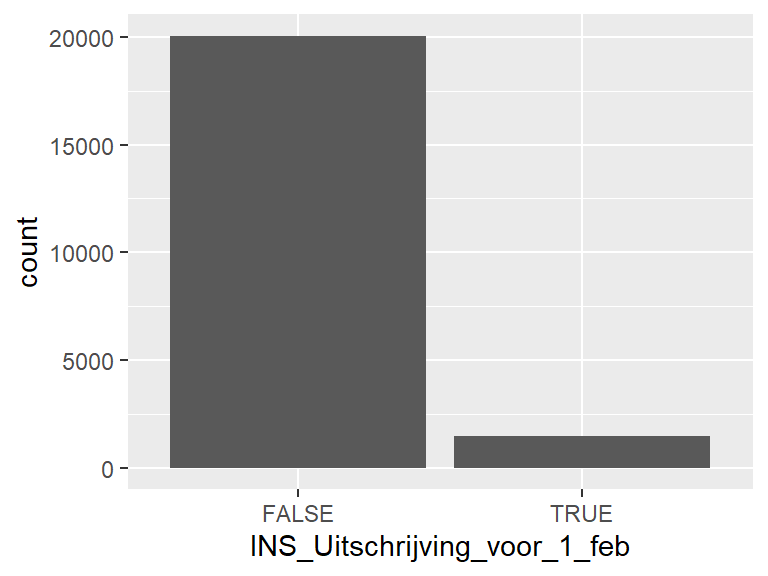

## INS_Uitschrijving_voor_1_feb_EOI

| Feature | Result |
| --- | --- |
| Variable type | logical |
| Number of missing obs. | 0 (0 %) |
| Number of unique values | 2 |
| Mode | “FALSE” |

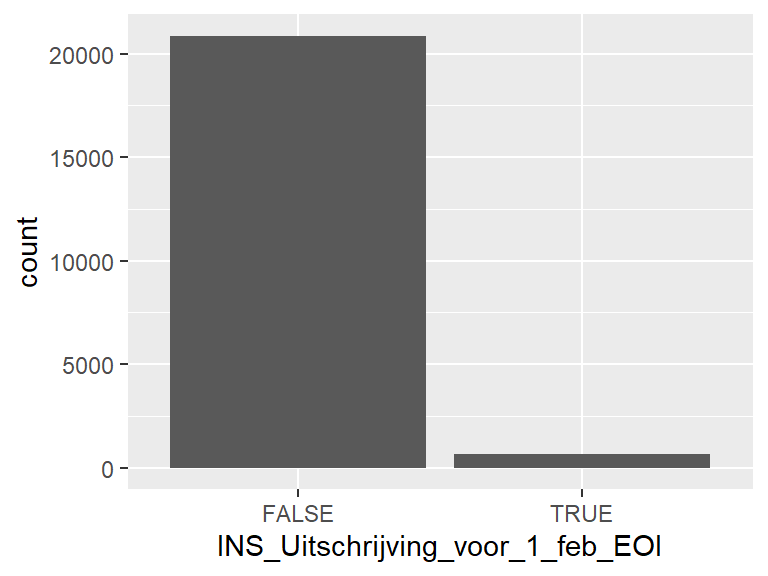

## INS_Herinschrijving_jaar_2_na_uitschrijving_voor_1_feb

| Feature | Result |
| --- | --- |
| Variable type | logical |
| Number of missing obs. | 0 (0 %) |
| Number of unique values | 2 |
| Mode | “FALSE” |

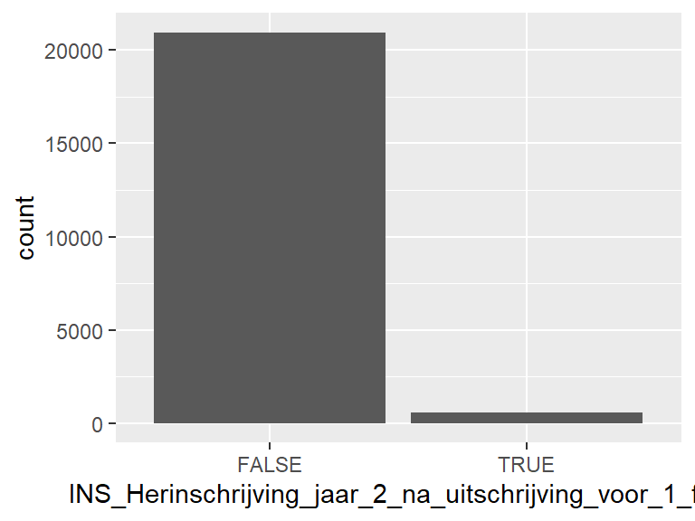

## INS_Studiejaar_gecorrigeerd_uitschrijving_1_feb_EOI

| Feature | Result |
| --- | --- |
| Variable type | numeric |
| Number of missing obs. | 0 (0 %) |
| Number of unique values | 12 |
| Median | 2 |
| 1st and 3rd quartiles | 1; 3 |
| Min. and max. | 1; 12 |

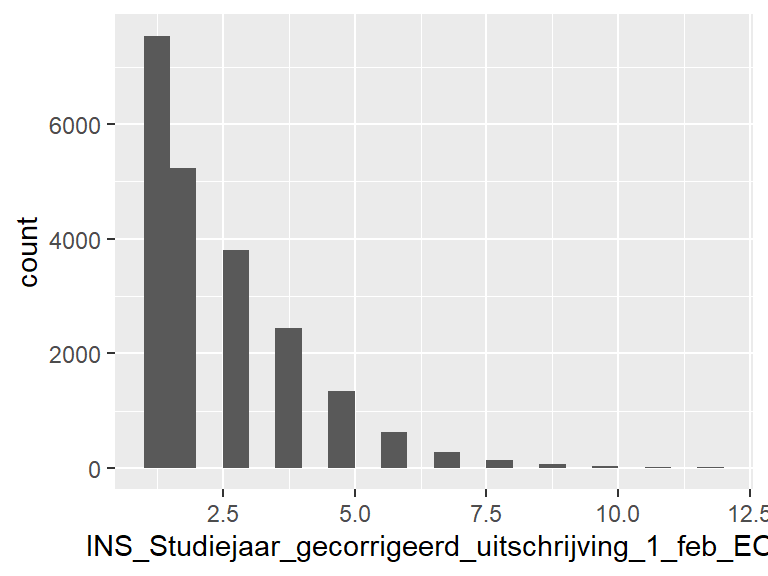

## INS_Direct

| Feature | Result |
| --- | --- |
| Variable type | logical |
| Number of missing obs. | 405 (1.88 %) |
| Number of unique values | 2 |
| Mode | “TRUE” |

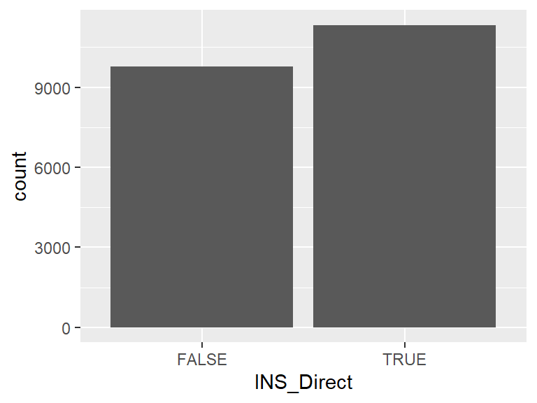

## INS_Indicatie_Tussenjaar_voor_B

| Feature | Result |
| --- | --- |
| Variable type | logical |
| Number of missing obs. | 343 (1.59 %) |
| Number of unique values | 2 |
| Mode | “FALSE” |

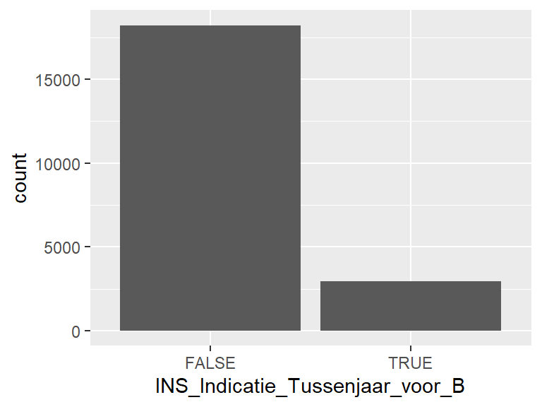

## INS_Indicatie_Tussenjaar_voor_P

- The variable only takes one (non-missing) value: "FALSE". The variable contains 0 % missing observations.

## INS_Indicatie_Tussenjaar_voor_M

| Feature | Result |
| --- | --- |
| Variable type | logical |
| Number of missing obs. | 298 (1.39 %) |
| Number of unique values | 2 |
| Mode | “FALSE” |

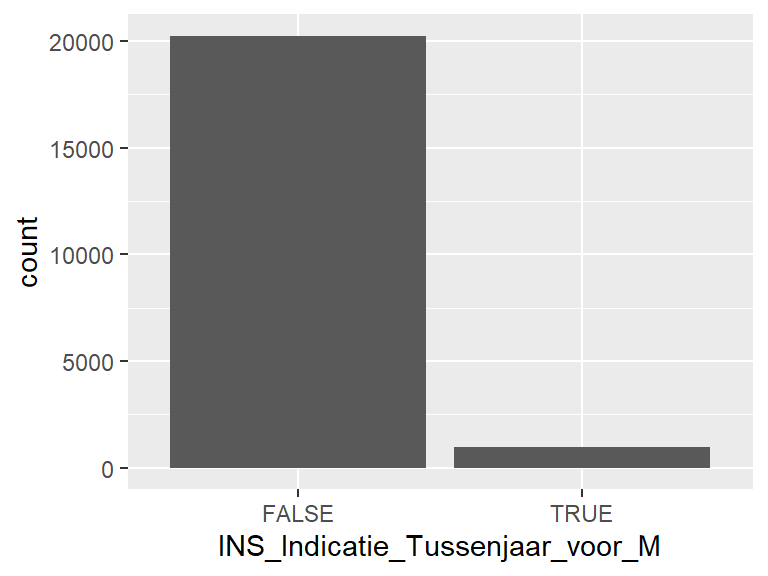

## INS_Indicatie_Tussenjaar

| Feature | Result |
| --- | --- |
| Variable type | logical |
| Number of missing obs. | 0 (0 %) |
| Number of unique values | 2 |
| Mode | “FALSE” |

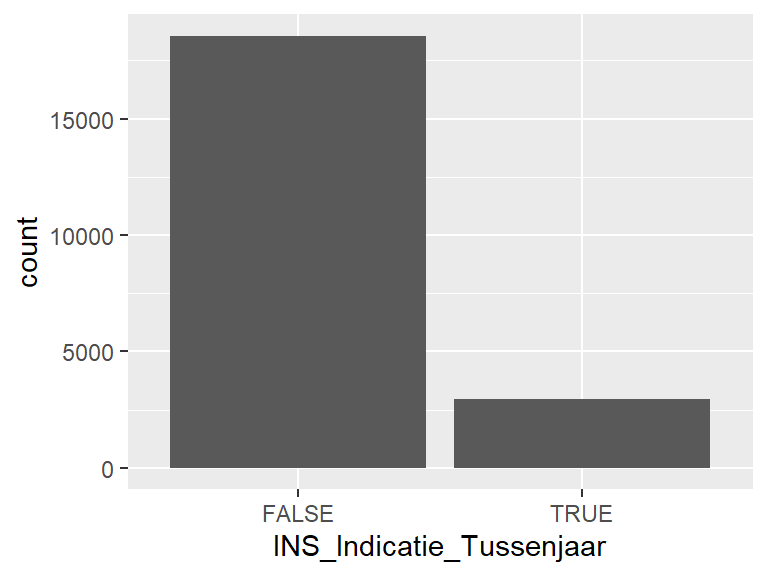

## INS_Aansluiting

| Feature | Result |
| --- | --- |
| Variable type | character |
| Number of missing obs. | 0 (0 %) |
| Number of unique values | 5 |
| Mode | “Direct na diploma extern” |

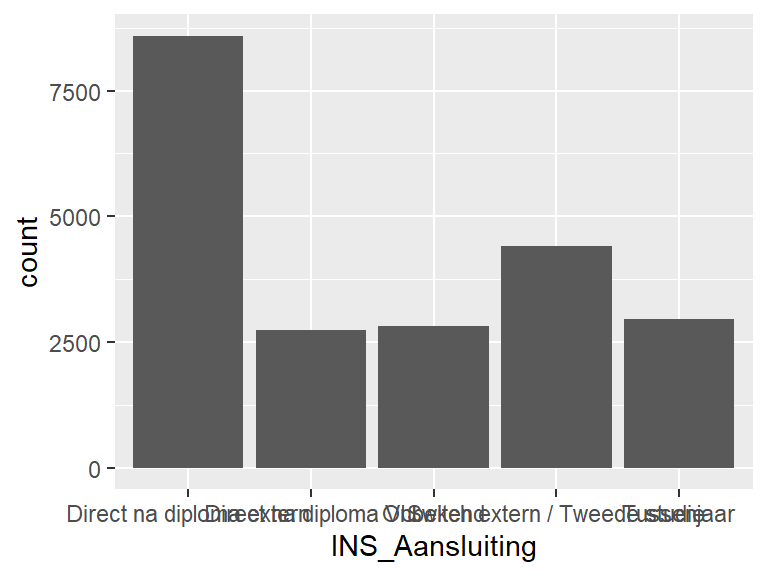

- Observed factor levels: "Direct na diploma extern", "Direct na diploma VU", "Onbekend", "Switch extern / Tweede studie", "Tussenjaar".

## INS_Soort_eerstejaars_code

| Feature | Result |
| --- | --- |
| Variable type | numeric |
| Number of missing obs. | 151 (0.7 %) |
| Number of unique values | 4 |
| Median | 2 |
| 1st and 3rd quartiles | 1; 4 |
| Min. and max. | 1; 4 |

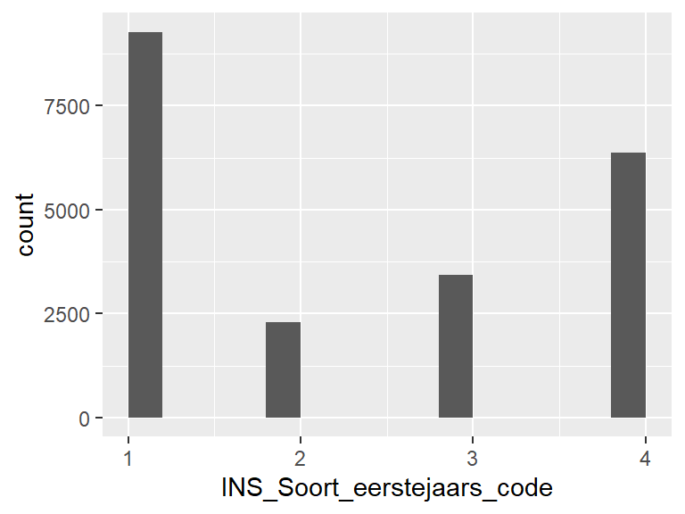

## INS_Aantal_inschrijvingen_in_HO

| Feature | Result |
| --- | --- |
| Variable type | numeric |
| Number of missing obs. | 151 (0.7 %) |
| Number of unique values | 5 |
| Median | 1 |
| 1st and 3rd quartiles | 1; 1 |
| Min. and max. | 1; 5 |

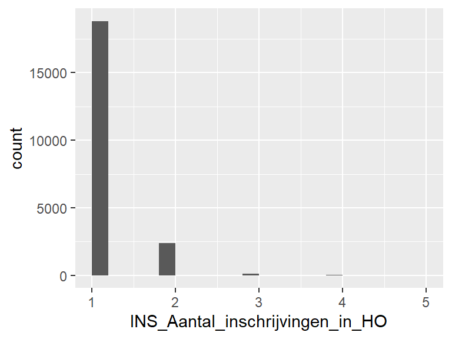

## INS_Herinschrijving_na_1_jaar

| Feature | Result |
| --- | --- |
| Variable type | numeric |
| Number of missing obs. | 1073 (4.99 %) |
| Number of unique values | 11 |
| Median | 1 |
| 1st and 3rd quartiles | 1; 1 |
| Min. and max. | 1; 12 |

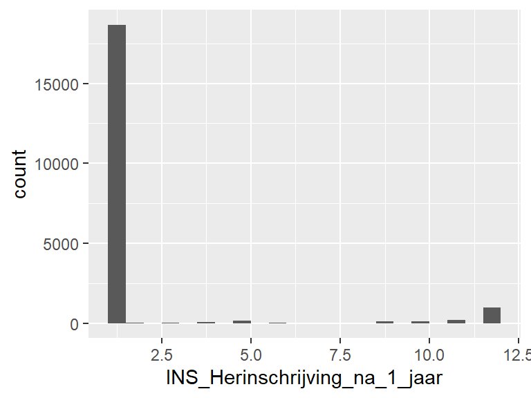

## INS_Herinschrijving_na_2_jaar

| Feature | Result |
| --- | --- |
| Variable type | numeric |
| Number of missing obs. | 2353 (10.94 %) |
| Number of unique values | 12 |
| Median | 1 |
| 1st and 3rd quartiles | 1; 5 |
| Min. and max. | 1; 12 |

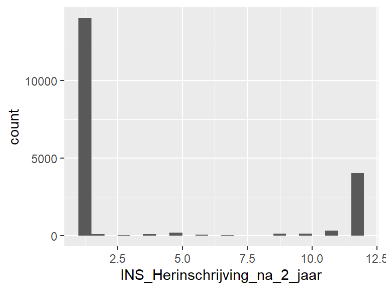

## INS_Herinschrijving_na_3_jaar

| Feature | Result |
| --- | --- |
| Variable type | numeric |
| Number of missing obs. | 3906 (18.16 %) |
| Number of unique values | 12 |
| Median | 2 |
| 1st and 3rd quartiles | 1; 12 |
| Min. and max. | 1; 12 |

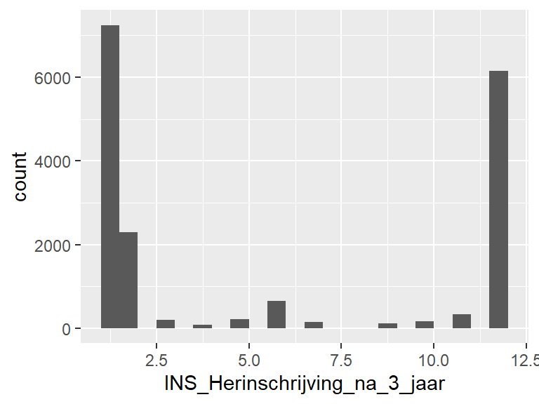